# Analysis of NY Subway traffic

by Mark Ayzenshtadt

## Section 0: References

Statistical test:  
http://statsthewayilikeit.com/about/statistical-test-flowchart/  
http://www.stat.ucla.edu/~rgould/x401f01/mannwhitney.html  
Regression residual analysis:  
http://blog.minitab.com/blog/adventures-in-statistics/why-you-need-to-check-your-residual-plots-for-regression-analysis  
http://www.originlab.com/doc/Origin-Help/Residual-Plot-Analysis

```python
'''Initialize'''
import pandas as pd
import numpy as np
import scipy.stats as st
from sklearn import linear_model
from ggplot import *
%matplotlib inline
import pprint
pp = pprint.PrettyPrinter()
data = pd.read_csv("turnstile_weather_v2.csv")
print 'The data consists of %s entries.\nThe columns are:'%len(data)
pp.pprint(list(data.columns.values))
```

```
The data consists of 42649 entries.
The columns are:
['UNIT',
 'DATEn',
 'TIMEn',
 'ENTRIESn',
 'EXITSn',
 'ENTRIESn_hourly',
 'EXITSn_hourly',
 'datetime',
 'hour',
 'day_week',
 'weekday',
 'station',
 'latitude',
 'longitude',
 'conds',
 'fog',
 'precipi',
 'pressurei',
 'rain',
 'tempi',
 'wspdi',
 'meanprecipi',
 'meanpressurei',
 'meantempi',
 'meanwspdi',
 'weather_lat',
 'weather_lon']
```

```python
'''Convert weather station coordinates to station numbers'''
data['weather_station'] = data.weather_lat.astype(str) + ',' + data.weather_lon.astype(str)
weather_stations = {value:key for key, value in dict(enumerate(set(data.weather_station), start = 1)).items()}
data.replace(weather_stations, inplace = True)
```

## Section 1. Statistical Test

As the data is not normally distributed and unpaired (see Section 3), we will use the Mann-Whitney test to check whether the rain will positively affect the hourly entries.  
The null hypothesis will be: "The medians of the distributions of the hourly entries with rain and without rain are the same."  
The alternative hypothesis: "The median of the distribution of the hourly entries with rain is higher than the median of the distribution of the entries without rain."

```python
'''Testing whether rain has an effect on ENTRIESn_hourly'''
data_rain   = data[data.rain == 1].ENTRIESn_hourly
data_norain = data[data.rain == 0].ENTRIESn_hourly
print 'Descriptive statistics for the rain sample:\n', data_rain.describe()
print '\nDescriptive statistics for the no-rain sample:\n', data_norain.describe(), '\n'
n1 = len(data_rain)
n2 = len(data_norain)
loc = n1*n2/2
scale = (n1*n2*(n1+n2+1)/12)**0.5
print "Mann-Whitney result: statistic = %.1f, pvalue = %.2e"%st.mannwhitneyu(data_norain, data_rain)
print "1%% left-sided critical value: %.1f"%float((st.norm.ppf(0.01)*scale + loc))
```

```
Descriptive statistics for the rain sample:
count     9585.000000
mean      2028.196035
std       3189.433373
min          0.000000
25%        295.000000
50%        939.000000
75%       2424.000000
max      32289.000000
Name: ENTRIESn_hourly, dtype: float64

Descriptive statistics for the no-rain sample:
count    33064.000000
mean      1845.539439
std       2878.770848
min          0.000000
25%        269.000000
50%        893.000000
75%       2197.000000
max      32814.000000
Name: ENTRIESn_hourly, dtype: float64

Mann-Whitney result: statistic = 153635120.5, pvalue = 2.74e-06
1% left-sided critical value: 155990241.5
```

The means are 2028.20 hourly entries when it rains, and 1845.54 entries when it doesn't.  
The (left-tailed) critical value for 1% significance level with sample sizes of n1 = 9585 and n2 = 33064 is 155990241.5.  
As the value of the statistic is less than this critical value, we reject the null hypothesis.  
The obtained p-value is 2.74×10<sup>-6</sup>.  
Thus, we can conclude that people use the subway more when it rains.

## Section 2. Linear Regression

For making the linear regression, we will use the OLS approach, as implemented in Scikit-Learn package.  
As features we will use:

- Weather variables: 'conds', 'fog', 'rain', 'precipi', 'pressurei', 'tempi', 'wspdi'
- General variables: 'UNIT', 'day_week', 'hour'

The features 'conds', 'UNIT', 'day_week', 'hour' are used as dummy features, because they are categorical.  
These features were chosen as they give an increase of R<sup>2</sup> value.  
The other possible features are strongly connected with the chosen features and thus were not included in the model.

The general variables are giving the most of the R<sup>2</sup>, because the difference between entries on the busy and quiet stations/hours can hardly be offset by weather conditions.  
Also, there are two factors to support this:

- the weather conditions do not vary much between stations at any given time
- we are using weather stations for estimating the weather conditions at the subway stations, thus homogenizing weather between stations even more.

```python
'''Regression'''
features_general = pd.get_dummies(data['hour'], prefix='hour')
features_general = features_general.join(pd.get_dummies(data['UNIT'], prefix='unit'))
features_general = features_general.join(pd.get_dummies(data['day_week'], prefix='day_week'))

weather_vars = [ 'fog', 'rain', 'precipi', 'pressurei', 'tempi', 'wspdi']
features_weather = pd.concat([data[weather_vars], pd.get_dummies(data['conds'], prefix='conds'),\
                              features_general], axis = 1)
values = data['ENTRIESn_hourly']
regression = linear_model.LinearRegression()
regression.fit(features_weather, values)
print 'R^2 = %.4f'%regression.score(features_weather, values)
print '\nCoefficients for non-dummy variables:'
pp.pprint(dict(zip(weather_vars , (regression.coef_[:len(weather_vars)]))))
```

```
R^2 = 0.5481

Coefficients for non-dummy variables:
{'fog': -885.53169667778184,
 'precipi': -4045.8443911145559,
 'pressurei': -437.03888568205474,
 'rain': -5.2685195492919092,
 'tempi': -19.77689354818218,
 'wspdi': 2.1774428157489574}
```

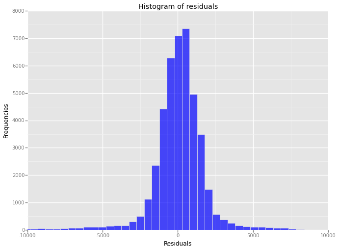

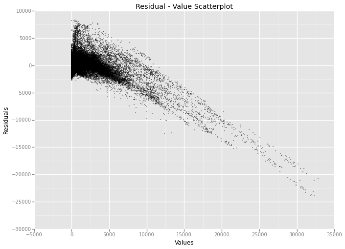

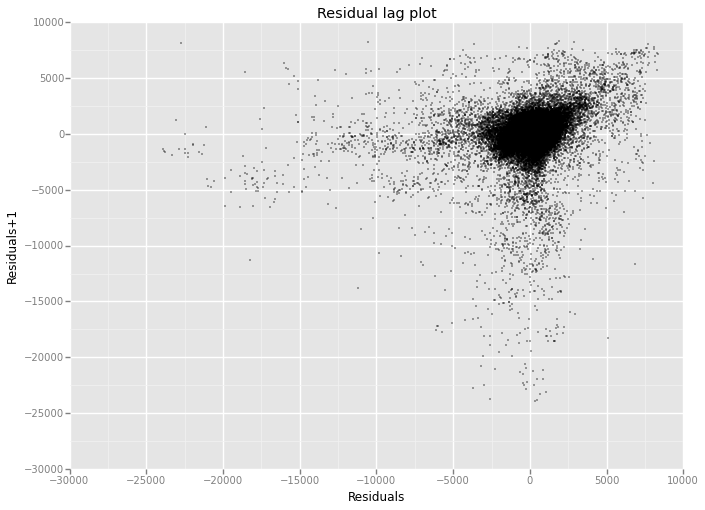

```python
'''Residual analysis'''
residuals = regression.predict(features_weather) - values
df_res = pd.DataFrame({'Residuals': residuals, 'Residuals+1': residuals.shift(),\
                       'UNIT': data.UNIT, 'Values': values})
print ggplot(aes('Residuals'),data = df_res)\
    + geom_histogram(binwidth = 500, fill = 'blue', alpha = 0.7) \
    + xlim(-10000,10000)\
    + ggtitle('Histogram of residuals')\
    + ylab('Frequencies')
print ggplot(aes(x = 'Values', y = 'Residuals'),data = df_res)\
    + geom_point(size = 0.5)\
    + ggtitle('Residual - Value Scatterplot')
print ggplot(aes(x = 'Residuals', y = 'Residuals+1'), data = df_res[1:-1])\
    + geom_point(size = 0.5)\
    + ggtitle('Residual lag plot')
```

We see, that while the residuals of the model are somewhat random for the low-traffic units and hours (less than 3000 entries through the unit per hour), the residuals clearly shift down when the traffic increases.  
As the samples for each unit are time-ordered, we can use the residual lag plot, which also shows non-random pattern.  
Thus, the linear model does not describe the actual relation accurately.

## Section 3. Visualization

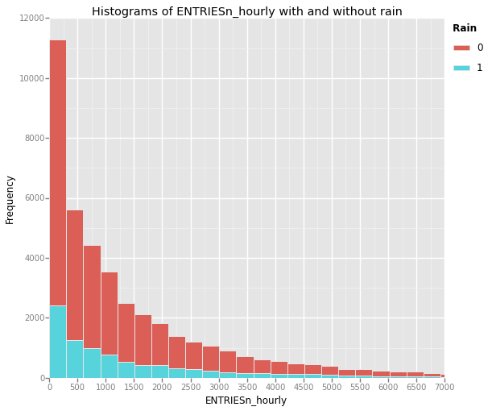

```python
'''Histograms of ENTRIESn_hourly with/without rain'''
print ggplot(aes('ENTRIESn_hourly', fill = 'rain'), data = data)\
    + geom_histogram(binwidth = 300, position = 'dodge')\
    + xlim(0,7000)\
    + ggtitle('Histograms of ENTRIESn_hourly with and without rain')\
    + ylab('Frequency')
```

We see that the distributions look similar, however, as we have confirmed by the test, the entries for rain sample are significantly higher.

```python
'''Convert weather station coordinates to station numbers'''
data['weather_station_coords'] = data.weather_lat.astype(str) + ',' + data.weather_lon.astype(str)
weather_stations = {value:key for key, value in dict(enumerate(set(data.weather_station), start = 1)).items()}
data['weather_station'] = data['weather_station_coords']
data.replace({'weather_station': weather_stations}, inplace=True)
data.weather_station = data.weather_station.astype(str)
data['coords'] = data.latitude.astype(str) + ',' + data.longitude.astype(str)
```

```python
'''Create DataFrame for map'''
map_units = data.drop_duplicates(subset = 'UNIT')\
    [['latitude','longitude','weather_station']]\
    .reset_index(drop = True)
map_units['is_weather'] = 0
map_weather = data.drop_duplicates(subset = 'weather_station')\
    [['weather_lat', 'weather_lon', 'weather_station']]
map_weather.columns = ['latitude','longitude','weather_station']
map_weather['is_weather'] = 1
map_df = map_units.append(map_weather)
```

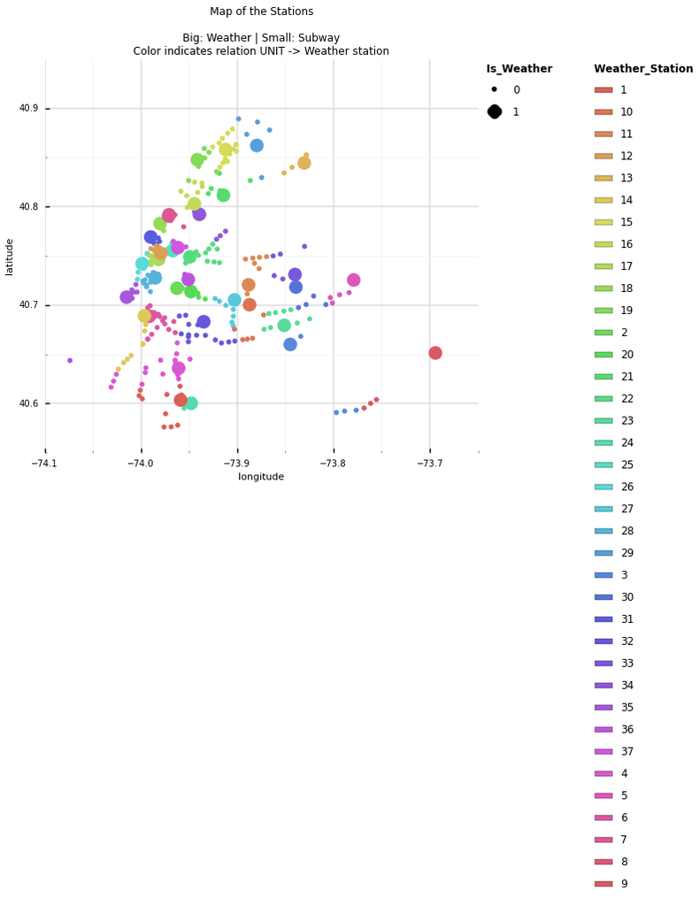

```python
'''Map of the weather and subway stations'''
print ggplot(aes(x = 'longitude',y = 'latitude' , color = 'weather_station', size = 'is_weather'), data = map_df)\
    + geom_point()\
    + ggtitle('Map of the Stations\n\nBig: Weather | Small: Subway\nColor indicates relation UNIT -> Weather station')\
    + theme_seaborn()
```

We see that the weather stations are not very well distributed between the subway stations, and thus the actual weather conditions at the subway station can differ from the data that we get from the weather stations.

## Section 4. Conclusion

With the Mann-Whitney test we have confirmed that the effect of rain on the hourly entries is significant and positive.  
Although the coefficient for the rain feature in the linear regression is negative, it's also very small: -5 compared to -885 for fog. Also we've established that the linear regression does not describe the relationship very well.

## Section 5. Reflection

The main shortcoming of the data is that the weather variables are not evaluated precisely at the time and location of the turnstile unit.  
Mainly, if we want to evaluate the effect of rain on other variables, we may want to know if it's raining at the exact time at which we measure the traffic. The variable 'rain', which indicates if rain occurred within the calendar day at the location, is only an estimate of that.  
Also, if our goal is to *predict* the *future* traffic by weather, we may want to base our analysis on the weather forecast, which, generally speaking, predicts the weather with only a certain accuracy.  
The linear regression does not describe the relationship very well, so if we want to capture the relationship between weather and subway traffic, we need to employ a more sophisticated model.  
Nevertheless, we have confirmed that rain positively affects the subway traffic, and when we expect heavy raining, the measures for handling increased traffic must be taken.